# Homework 2 — Incident rates and unequal exposure

STA5001 Bayesian & Computational Statistics

The starter code uses the BayesComp package from this checkout. To install it, run `R CMD INSTALL BayesComp` from the repository root.

**Concept.** A Poisson count updates an event rate through both the count and the exposure time. For prediction, uncertainty about the rate adds variation to the new count.

**Example.** The synthetic data contain 16 monitoring windows of different lengths. For window $i$ let $e_i$ be the exposure in hours and $Y_i$ its incident count. Assume independent $Y_i\mid\lambda\sim \operatorname{Poisson}(e_i\lambda)$ and $\lambda\sim \operatorname{Gamma}(2,2)$, with Gamma parameters given as shape and rate. The future monitoring window lasts four hours. Estimate the chance of more than four incidents in that window.

**Starter code.** Check that the exposures are positive and view the raw counts against exposure. The horizontal axis is measured in hours.

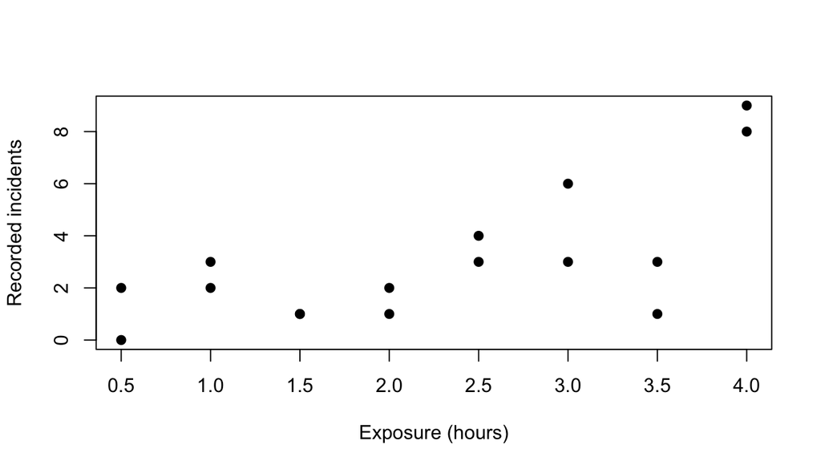

Synthetic counts by monitoring time. Marks may overlap.

```r
data("hw02_incidents", package = "BayesComp")
stopifnot(all(hw02_incidents$exposure_hours > 0),
          all(hw02_incidents$incidents >= 0))
plot(incidents ~ exposure_hours, data = hw02_incidents, pch = 19,
     xlab = "Exposure (hours)", ylab = "Recorded incidents")
```

## Tasks

1. **Update the rate.** Identify the two data summaries that determine the posterior parameters. Compute the posterior mean and a 95% equal-tailed credible interval for $\lambda$, in incidents per hour.
2. **Predict the count.** Determine the negative-binomial posterior predictive distribution for the four-hour window. Independently check $\Pr(Y_\star>4\mid\mathbf y)$ by composition sampling with 20,000 posterior rate draws and one Poisson count per draw. Report the exact probability, simulation estimate, and iid MCSE.
3. **Compare predictive variation.** Use the posterior mean rate in a plug-in Poisson forecast for the same window. Compare its variance and exceedance probability with those from the integrated forecast. Explain how the law of total variance accounts for their difference.

**Outputs and visuals.** Report the posterior rate summary and a table comparing the two forecasts. Overlay their probability masses on one integer count axis, and mark where the exceedance event begins.

**Public-data reference.** The R dataset `discoveries` gives annual counts of inventions and scientific discoveries as an example with equal-length observation windows. [R documentation for discoveries](https://stat.ethz.ch/R-manual/R-devel/library/datasets/html/discoveries.html)

R 4.6.0 · BayesComp 0.1.0